# Project Code

Sneaky Pythons

Author

Alissa Chu, Adam Ruzumna, and Judd Moss

Published

February 27, 2023

Abstract

```python
# import packages
import pandas as pd
import numpy as np
import statsmodels.formula.api as sm
import seaborn as sns
import matplotlib.pyplot as plt
import itertools
import time
```

```python
# import dataset
data = pd.read_csv('Life_Expectancy_Data.csv')
```

## 1 Data quality check / cleaning / preparation

### 1.1 Data quality check

*By Adam Ruzumna*

The code below visualizes the distribution of all the variables in the dataset, and their association with the response.

```python
#...Distribution of continuous variables...#
data.describe()
```

|  | Year | Life expectancy | Adult Mortality | infant deaths | Alcohol | percentage expenditure | Hepatitis B | Measles | BMI | under-five deaths | Polio | Total expenditure | Diphtheria | HIV/AIDS | GDP | Population | thinness 1-19 years | thinness 5-9 years | Income composition of resources | Schooling |
| --- | --- | --- | --- | --- | --- | --- | --- | --- | --- | --- | --- | --- | --- | --- | --- | --- | --- | --- | --- | --- |
| count | 2938.000000 | 2928.000000 | 2928.000000 | 2938.000000 | 2744.000000 | 2938.000000 | 2385.000000 | 2938.000000 | 2904.000000 | 2938.000000 | 2919.000000 | 2712.00000 | 2919.000000 | 2938.000000 | 2490.000000 | 2.286000e+03 | 2904.000000 | 2904.000000 | 2771.000000 | 2775.000000 |
| mean | 2007.518720 | 69.224932 | 164.796448 | 30.303948 | 4.602861 | 738.251295 | 80.940461 | 2419.592240 | 38.321247 | 42.035739 | 82.550188 | 5.93819 | 82.324084 | 1.742103 | 7483.158469 | 1.275338e+07 | 4.839704 | 4.870317 | 0.627551 | 11.992793 |
| std | 4.613841 | 9.523867 | 124.292079 | 117.926501 | 4.052413 | 1987.914858 | 25.070016 | 11467.272489 | 20.044034 | 160.445548 | 23.428046 | 2.49832 | 23.716912 | 5.077785 | 14270.169342 | 6.101210e+07 | 4.420195 | 4.508882 | 0.210904 | 3.358920 |
| min | 2000.000000 | 36.300000 | 1.000000 | 0.000000 | 0.010000 | 0.000000 | 1.000000 | 0.000000 | 1.000000 | 0.000000 | 3.000000 | 0.37000 | 2.000000 | 0.100000 | 1.681350 | 3.400000e+01 | 0.100000 | 0.100000 | 0.000000 | 0.000000 |
| 25% | 2004.000000 | 63.100000 | 74.000000 | 0.000000 | 0.877500 | 4.685343 | 77.000000 | 0.000000 | 19.300000 | 0.000000 | 78.000000 | 4.26000 | 78.000000 | 0.100000 | 463.935626 | 1.957932e+05 | 1.600000 | 1.500000 | 0.493000 | 10.100000 |
| 50% | 2008.000000 | 72.100000 | 144.000000 | 3.000000 | 3.755000 | 64.912906 | 92.000000 | 17.000000 | 43.500000 | 4.000000 | 93.000000 | 5.75500 | 93.000000 | 0.100000 | 1766.947595 | 1.386542e+06 | 3.300000 | 3.300000 | 0.677000 | 12.300000 |
| 75% | 2012.000000 | 75.700000 | 228.000000 | 22.000000 | 7.702500 | 441.534144 | 97.000000 | 360.250000 | 56.200000 | 28.000000 | 97.000000 | 7.49250 | 97.000000 | 0.800000 | 5910.806335 | 7.420359e+06 | 7.200000 | 7.200000 | 0.779000 | 14.300000 |
| max | 2015.000000 | 89.000000 | 723.000000 | 1800.000000 | 17.870000 | 19479.911610 | 99.000000 | 212183.000000 | 87.300000 | 2500.000000 | 99.000000 | 17.60000 | 99.000000 | 50.600000 | 119172.741800 | 1.293859e+09 | 27.700000 | 28.600000 | 0.948000 | 20.700000 |

```python
data.columns
```

```
Index(['Country', 'Year', 'Status', 'Life expectancy ', 'Adult Mortality',
       'infant deaths', 'Alcohol', 'percentage expenditure', 'Hepatitis B',
       'Measles ', ' BMI ', 'under-five deaths ', 'Polio', 'Total expenditure',
       'Diphtheria ', ' HIV/AIDS', 'GDP', 'Population',
       ' thinness  1-19 years', ' thinness 5-9 years',
       'Income composition of resources', 'Schooling'],
      dtype='object')
```

```
Developing    2426
Developed      512
Name: Status, dtype: int64
```

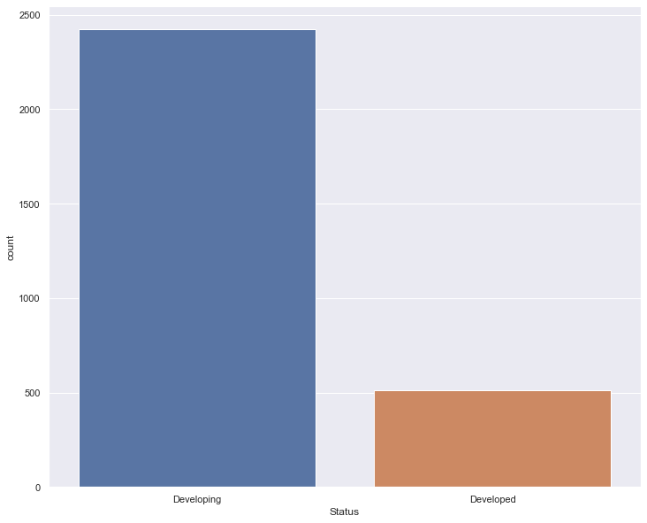

```python
# Distribution of categorical variables
print(data['Status'].value_counts())

# Visualization of the distribution of the categorical variable
sns.countplot(x='Status', data=data)
```

```python
#...Association of the response with the predictors...#
data.corr()
```

|  | Year | Life expectancy | Adult Mortality | infant deaths | Alcohol | percentage expenditure | Hepatitis B | Measles | BMI | under-five deaths | Polio | Total expenditure | Diphtheria | HIV/AIDS | GDP | Population | thinness 1-19 years | thinness 5-9 years | Income composition of resources | Schooling |
| --- | --- | --- | --- | --- | --- | --- | --- | --- | --- | --- | --- | --- | --- | --- | --- | --- | --- | --- | --- | --- |
| Year | 1.000000 | 0.170033 | -0.079052 | -0.037415 | -0.052990 | 0.031400 | 0.104333 | -0.082493 | 0.108974 | -0.042937 | 0.094158 | 0.090740 | 0.134337 | -0.139741 | 0.101620 | 0.016969 | -0.047876 | -0.050929 | 0.243468 | 0.209400 |
| Life expectancy | 0.170033 | 1.000000 | -0.696359 | -0.196557 | 0.404877 | 0.381864 | 0.256762 | -0.157586 | 0.567694 | -0.222529 | 0.465556 | 0.218086 | 0.479495 | -0.556556 | 0.461455 | -0.021538 | -0.477183 | -0.471584 | 0.724776 | 0.751975 |
| Adult Mortality | -0.079052 | -0.696359 | 1.000000 | 0.078756 | -0.195848 | -0.242860 | -0.162476 | 0.031176 | -0.387017 | 0.094146 | -0.274823 | -0.115281 | -0.275131 | 0.523821 | -0.296049 | -0.013647 | 0.302904 | 0.308457 | -0.457626 | -0.454612 |
| infant deaths | -0.037415 | -0.196557 | 0.078756 | 1.000000 | -0.115638 | -0.085612 | -0.223566 | 0.501128 | -0.227279 | 0.996629 | -0.170689 | -0.128616 | -0.175171 | 0.025231 | -0.108427 | 0.556801 | 0.465711 | 0.471350 | -0.145139 | -0.193720 |
| Alcohol | -0.052990 | 0.404877 | -0.195848 | -0.115638 | 1.000000 | 0.341285 | 0.087549 | -0.051827 | 0.330408 | -0.112370 | 0.221734 | 0.296942 | 0.222020 | -0.048845 | 0.354712 | -0.035252 | -0.428795 | -0.417414 | 0.450040 | 0.547378 |
| percentage expenditure | 0.031400 | 0.381864 | -0.242860 | -0.085612 | 0.341285 | 1.000000 | 0.016274 | -0.056596 | 0.228700 | -0.087852 | 0.147259 | 0.174420 | 0.143624 | -0.097857 | 0.899373 | -0.025662 | -0.251369 | -0.252905 | 0.381952 | 0.389687 |
| Hepatitis B | 0.104333 | 0.256762 | -0.162476 | -0.223566 | 0.087549 | 0.016274 | 1.000000 | -0.120529 | 0.150380 | -0.233126 | 0.486171 | 0.058280 | 0.611495 | -0.112675 | 0.083903 | -0.123321 | -0.120429 | -0.124960 | 0.199549 | 0.231117 |
| Measles | -0.082493 | -0.157586 | 0.031176 | 0.501128 | -0.051827 | -0.056596 | -0.120529 | 1.000000 | -0.175977 | 0.507809 | -0.136166 | -0.106241 | -0.141882 | 0.030899 | -0.076466 | 0.265966 | 0.224808 | 0.221072 | -0.129568 | -0.137225 |
| BMI | 0.108974 | 0.567694 | -0.387017 | -0.227279 | 0.330408 | 0.228700 | 0.150380 | -0.175977 | 1.000000 | -0.237669 | 0.284569 | 0.242503 | 0.283147 | -0.243717 | 0.301557 | -0.072301 | -0.532025 | -0.538911 | 0.508774 | 0.546961 |
| under-five deaths | -0.042937 | -0.222529 | 0.094146 | 0.996629 | -0.112370 | -0.087852 | -0.233126 | 0.507809 | -0.237669 | 1.000000 | -0.188720 | -0.130148 | -0.195668 | 0.038062 | -0.112081 | 0.544423 | 0.467789 | 0.472263 | -0.163305 | -0.209373 |
| Polio | 0.094158 | 0.465556 | -0.274823 | -0.170689 | 0.221734 | 0.147259 | 0.486171 | -0.136166 | 0.284569 | -0.188720 | 1.000000 | 0.137330 | 0.673553 | -0.159560 | 0.211976 | -0.038540 | -0.221823 | -0.222592 | 0.381078 | 0.417866 |
| Total expenditure | 0.090740 | 0.218086 | -0.115281 | -0.128616 | 0.296942 | 0.174420 | 0.058280 | -0.106241 | 0.242503 | -0.130148 | 0.137330 | 1.000000 | 0.152754 | -0.001389 | 0.138364 | -0.079662 | -0.277101 | -0.283774 | 0.166682 | 0.246384 |
| Diphtheria | 0.134337 | 0.479495 | -0.275131 | -0.175171 | 0.222020 | 0.143624 | 0.611495 | -0.141882 | 0.283147 | -0.195668 | 0.673553 | 0.152754 | 1.000000 | -0.164860 | 0.200666 | -0.028444 | -0.229518 | -0.222743 | 0.401456 | 0.425332 |
| HIV/AIDS | -0.139741 | -0.556556 | 0.523821 | 0.025231 | -0.048845 | -0.097857 | -0.112675 | 0.030899 | -0.243717 | 0.038062 | -0.159560 | -0.001389 | -0.164860 | 1.000000 | -0.136491 | -0.027854 | 0.204064 | 0.207283 | -0.249519 | -0.220429 |
| GDP | 0.101620 | 0.461455 | -0.296049 | -0.108427 | 0.354712 | 0.899373 | 0.083903 | -0.076466 | 0.301557 | -0.112081 | 0.211976 | 0.138364 | 0.200666 | -0.136491 | 1.000000 | -0.028270 | -0.285697 | -0.290539 | 0.460341 | 0.448273 |
| Population | 0.016969 | -0.021538 | -0.013647 | 0.556801 | -0.035252 | -0.025662 | -0.123321 | 0.265966 | -0.072301 | 0.544423 | -0.038540 | -0.079662 | -0.028444 | -0.027854 | -0.028270 | 1.000000 | 0.253944 | 0.251403 | -0.008735 | -0.031668 |
| thinness 1-19 years | -0.047876 | -0.477183 | 0.302904 | 0.465711 | -0.428795 | -0.251369 | -0.120429 | 0.224808 | -0.532025 | 0.467789 | -0.221823 | -0.277101 | -0.229518 | 0.204064 | -0.285697 | 0.253944 | 1.000000 | 0.939102 | -0.422429 | -0.471652 |
| thinness 5-9 years | -0.050929 | -0.471584 | 0.308457 | 0.471350 | -0.417414 | -0.252905 | -0.124960 | 0.221072 | -0.538911 | 0.472263 | -0.222592 | -0.283774 | -0.222743 | 0.207283 | -0.290539 | 0.251403 | 0.939102 | 1.000000 | -0.411053 | -0.460632 |
| Income composition of resources | 0.243468 | 0.724776 | -0.457626 | -0.145139 | 0.450040 | 0.381952 | 0.199549 | -0.129568 | 0.508774 | -0.163305 | 0.381078 | 0.166682 | 0.401456 | -0.249519 | 0.460341 | -0.008735 | -0.422429 | -0.411053 | 1.000000 | 0.800092 |
| Schooling | 0.209400 | 0.751975 | -0.454612 | -0.193720 | 0.547378 | 0.389687 | 0.231117 | -0.137225 | 0.546961 | -0.209373 | 0.417866 | 0.246384 | 0.425332 | -0.220429 | 0.448273 | -0.031668 | -0.471652 | -0.460632 | 0.800092 | 1.000000 |

```python
# Amount of missing data before any cleaning
data.isnull().sum()
```

```
Country                              0
Year                                 0
Status                               0
Life expectancy                     10
Adult Mortality                     10
infant deaths                        0
Alcohol                            194
percentage expenditure               0
Hepatitis B                        553
Measles                              0
 BMI                                34
under-five deaths                    0
Polio                               19
Total expenditure                  226
Diphtheria                          19
 HIV/AIDS                            0
GDP                                448
Population                         652
 thinness  1-19 years               34
 thinness 5-9 years                 34
Income composition of resources    167
Schooling                          163
dtype: int64
```

### 1.2 Data cleaning

*By Adam Ruzumna*

From the data quality check we realized that:

1. For `population`, `bmi`, and `infant_deaths`, we found that the dataset contained enough inaccurate data where the variables were not worth including. For infant_deaths in particular, the mean value was 30.3 deaths per 1000 births– despite the world’s current highest value being 27. Population and bmi had similarly suspect values. Some of these were found by manually inspecting the data.
2. For `hepatitis_b`, `alcohol`, and `total_expenditure`, the data was not inaccurate, but these variables had little correlation to our variable of interest and they had a number of missing values. Thus, we decided that they were better to exclude from our dataset rather than drop the entire row because of on missing value. We were hesitant to impute values for these variables, since we felt that countries situations are too complex for us to assume a particular value.
3. Next, we dropped the missing values from the `gdp_per_capita` and’income_composition_of_resources’ columns. These variables were both important for our model, and thus felt they were important to include.
4. The `gdp_per_capita` and `under_five_deaths` variables were generally consistent, but had some suspect data points. We needed to filter `gdp_per_capita` to be above 108 – the lowest value at the time period– and filter `under_five_deaths` to be below 225 – the highest value for the time period.
5. Finally, we had to change the names of all of our columns to be in a consistent manner that clearly depicted not only the content of the data, but also allowed us to run the code smoothly.

The code below implements the above cleaning.

```python
# clean column names
data.columns = data.columns.str.strip().str.lower().str.replace(' ', '_').str.replace('(', '').str.replace(')', '')

# rename gdp column to make data more understandable
data = data.rename(columns={'gdp': 'gdp_per_capita'})

# rename HIV/AIDs column to make it usable
data = data.rename(columns={'hiv/aids': 'hiv_aids'})

# rename thinness 1-19 column to make it usable
data = data.rename(columns={'thinness__1-19_years': 'thinness_1_19_years'})

# rename thinness 5-9 column to make it usable
data = data.rename(columns={'thinness_5-9_years': 'thinness_5_9_years'})

# rename under five deaths column to make it usable
data = data.rename(columns={'under-five_deaths': 'under_five_deaths'})
```

```python
# Drop columns with suspect data

# Dropping 'population' column
data.drop(columns=['population', 'bmi', 'infant_deaths', 'percentage_expenditure', 'hepatitis_b', 'alcohol', 'total_expenditure'],inplace=True)
    # population: data inconsistent and inaccurate
    # bmi: max bmi is over 80, which does not make sense -- lots of values like this
    # infant_deaths: mean value is 29-- true world highest value is 27
    # percentage_expenditure: seems very inaccurate, large number of values over 100%
```

```python
# Additional Cleaning -- Dropping Missing Values

# drop missing gdp, life_expectancy, income_composition_of_resources values,
data = data.dropna(subset=['gdp_per_capita','income_composition_of_resources'])
```

```python
# Dropping rows with unreasonable gdp_per_capita values
    # the number 108 is chosen because an outside source confirmed that the lowest
    # gdp per capita during this time period is 108
data = data.loc[data.gdp_per_capita >= 108]

# Dropping rows with unreasonable under_five_deaths values
    # the number 180 is chosen because an outside source confirmed that the highest value should be 225 for this period
data = data.loc[data.under_five_deaths <= 225]
```

```python
# reset the index numbers

data = data.reset_index(drop=True)
data = data.dropna()
```

### 1.3 Data preparation

*By Adam Ruzumna and Judd Moss*

- Our final data prepartion was to add in continents to be a categorical variable and split the dataset in to training and testing datasets

```python
# add in continents to be a categorical variable
continents_df = pd.read_csv('gdp_lifeExpectancy.csv')
continents = continents_df[['country', 'continent']]
continents.head(1)
```

|  | country | continent |
| --- | --- | --- |
| 0 | Afghanistan | Asia |

```python
data = pd.merge(data, continents, on='country')
```

```python
data.head(1)
```

|  | country | year | status | life_expectancy | adult_mortality | measles | under_five_deaths | polio | diphtheria | hiv_aids | gdp_per_capita | thinness_1_19_years | thinness_5_9_years | income_composition_of_resources | schooling | continent |
| --- | --- | --- | --- | --- | --- | --- | --- | --- | --- | --- | --- | --- | --- | --- | --- | --- |
| 0 | Afghanistan | 2015 | Developing | 65.0 | 263.0 | 1154 | 83 | 6.0 | 65.0 | 0.1 | 584.25921 | 17.2 | 17.3 | 0.479 | 10.1 | Asia |

```python
# dividing data into 80% training, 20% test
np.random.seed(2)
train = data.sample(round(data.shape[0]*0.8)) # 80% training, 20% test
test = data.drop(train.index)
```

## 2 Exploratory data analysis

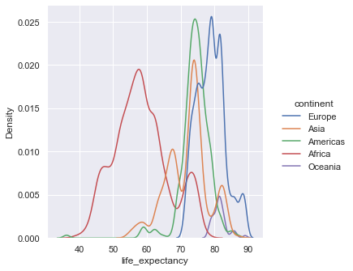

```python
# Exploring different distributions of life expectancy by continent - Judd Moss
sns.displot(data = train, x = 'life_expectancy',kind = 'kde', hue='continent').set_titles("Life Expectancy Distribution by Continent")
plt.show()
```

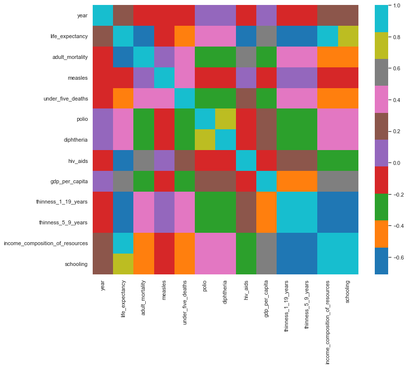

```python
# check the correlation with life_expectancy and the potential predictors - Judd Moss
sns.set(rc={'figure.figsize':(12,10)})
sns.heatmap(train.corr(), cmap='tab10')
```

- The variable most correlated with life expectancy was `income_composition_of_resources` so we wanted to check its distribution since it was on a 0-1 scale to see where most countries fell on the scale

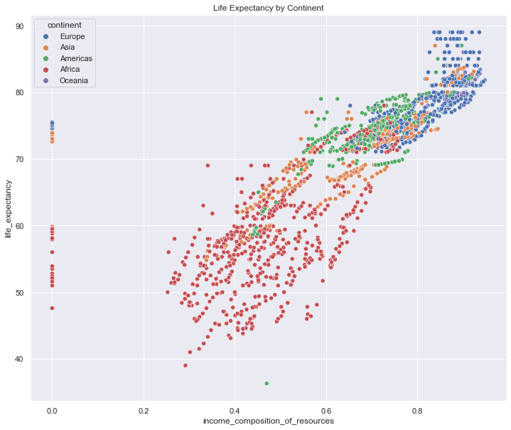

```python
# check scatterplot of income_composition_of_resources and life expectancy - Judd
ax = sns.scatterplot(data = train, x = 'income_composition_of_resources',y = 'life_expectancy', hue='continent')
ax.set_title("Life Expectancy by Continent")
plt.show()
```

- `income_composition_of_resources` measures on a scale of 0 to 1, a countries ability to utilize its resources. We can see many of the countries with values of `income_composition_of_resources` have a higher life expectancy.

## 3 Developing the model

*By Judd Moss and Alissa Chu*

**Addressing Multicollinearity** - In the following code chunk, we tested the multicollinearity of the predictors that could be used in our regression model. Since many of the healthcare variables were related we suspected the predictors would exhibit some collinearity. To check this, we computed their VIF values

```python
#Predictors VIF will be caluclated for:

X = train[['adult_mortality','measles', 'under_five_deaths', 'polio', 'diphtheria', 'hiv_aids',
           'gdp_per_capita', 'thinness_1_19_years', 'thinness_5_9_years',
           'income_composition_of_resources', 'schooling']]

from statsmodels.stats.outliers_influence import variance_inflation_factor
from statsmodels.tools.tools import add_constant

# add constant column
X = add_constant(X)
# create empty dataframe to input VIF values
vif_data=pd.DataFrame()
# create row for each predictor in X
vif_data['predictor'] = X.columns

# for loop to fill in VIF values
for i in range(len(X.columns)):
    vif_data.loc[i,'VIF'] = variance_inflation_factor(X.values,i)

print(vif_data)
```

```
                          predictor        VIF
0                             const  53.002345
1                   adult_mortality   1.974252
2                           measles   1.196678
3                 under_five_deaths   1.623588
4                             polio   2.176984
5                        diphtheria   2.182067
6                          hiv_aids   1.573704
7                    gdp_per_capita   1.453658
8               thinness_1_19_years   9.239179
9                thinness_5_9_years   9.201331
10  income_composition_of_resources   4.842720
11                        schooling   4.856786
```

```python
data.corrwith(data.life_expectancy).sort_values(ascending=False)
```

```
life_expectancy                    1.000000
income_composition_of_resources    0.830276
schooling                          0.806966
diphtheria                         0.487223
gdp_per_capita                     0.486544
polio                              0.470361
year                               0.154529
measles                           -0.173098
under_five_deaths                 -0.517525
thinness_1_19_years               -0.580836
thinness_5_9_years                -0.581806
hiv_aids                          -0.588924
adult_mortality                   -0.711417
dtype: float64
```

**Model Selection** - We ran a forward stepwise selection algorithm to help determine which variables we should use in our model.

```python
#Creating a dataframe with all the predictors
X = train[['adult_mortality', 'measles', 'under_five_deaths', 'polio', 'diphtheria', 'hiv_aids', 'gdp_per_capita', 'thinness_1_19_years', 'income_composition_of_resources']]
```

```python
#Function to develop a model based on all predictors in predictor_subset
def processSubset(predictor_subset):
    # Fit model on feature_set and calculate R-squared
    model = sm.ols('life_expectancy~' + '+'.join(predictor_subset),data = train).fit()
    Rsquared = model.rsquared
    return {"model":model, "Rsquared":Rsquared}
```

```python
#Function to find the best predictor out of p-k predictors and add it to the model containing the k predictors
def forward(predictors):

    # Pull out predictors we still need to process
    remaining_predictors = [p for p in X.columns if p not in predictors]

    results = []

    for p in remaining_predictors:
        results.append(processSubset(predictors+[p]))

    # Wrap everything up in a nice dataframe
    models = pd.DataFrame(results)

    # Choose the model with the highest RSS
    best_model = models.loc[models['Rsquared'].argmax()]

    print("Processed ", models.shape[0], "models on", len(predictors)+1, "predictors")

    # Return the best model, along with some other useful information about the model
    return best_model
```

```python
def forward_selection():
    models_best = pd.DataFrame(columns=["Rsquared", "model"])

    predictors = []

    for i in range(1,len(X.columns)+1):
        models_best.loc[i] = forward(predictors)
        predictors = list(models_best.loc[i]["model"].params.index[1:])

    return models_best
```

```python
models_best = forward_selection()
```

```
Processed  9 models on 1 predictors
Processed  8 models on 2 predictors
Processed  7 models on 3 predictors
Processed  6 models on 4 predictors
Processed  5 models on 5 predictors
Processed  4 models on 6 predictors
Processed  3 models on 7 predictors
Processed  2 models on 8 predictors
Processed  1 models on 9 predictors
```

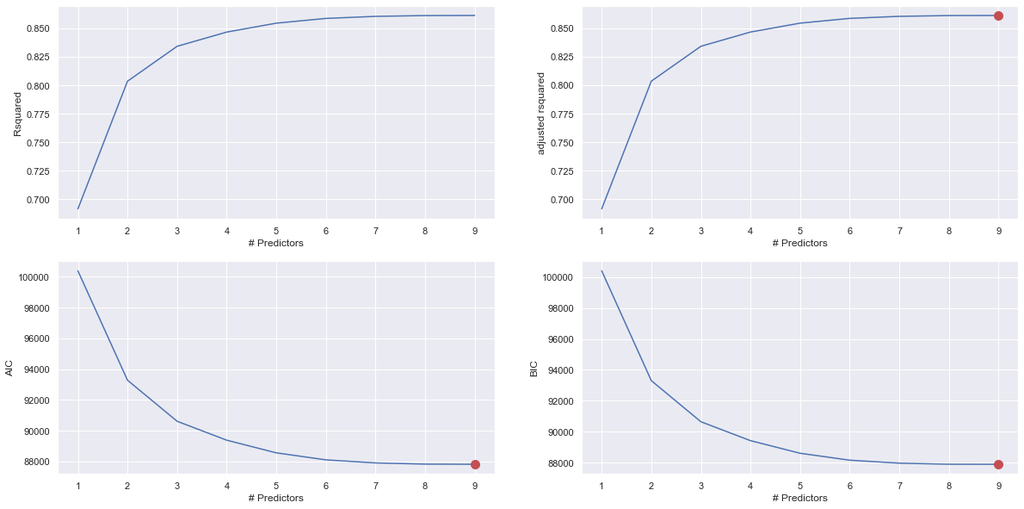

```python
# define function to assess which model is the best using AIC, BIC and adjusted R2
def best_sub_plots():
    plt.figure(figsize=(20,10))
    plt.rcParams.update({'font.size': 18, 'lines.markersize': 10})

    # Set up a 2x2 grid so we can look at 4 plots at once
    plt.subplot(2, 2, 1)

    # We will now plot a red dot to indicate the model with the largest adjusted R^2 statistic.
    # The argmax() function can be used to identify the location of the maximum point of a vector
    plt.plot(models_best["Rsquared"])
    plt.xlabel('# Predictors')
    plt.ylabel('Rsquared')

    # We will now plot a red dot to indicate the model with the largest adjusted R^2 statistic.
    # The argmax() function can be used to identify the location of the maximum point of a vector

    rsquared_adj = models_best.apply(lambda row: row[1].rsquared_adj, axis=1)

    plt.subplot(2, 2, 2)
    plt.plot(rsquared_adj)
    plt.plot(1+rsquared_adj.argmax(), rsquared_adj.max(), "or")
    plt.xlabel('# Predictors')
    plt.ylabel('adjusted rsquared')

    # We'll do the same for AIC and BIC, this time looking for the models with the SMALLEST statistic
    aic = models_best.apply(lambda row: row[1].aic, axis=1)

    plt.subplot(2, 2, 3)
    plt.plot(aic)
    plt.plot(1+aic.argmin(), aic.min(), "or")
    plt.xlabel('# Predictors')
    plt.ylabel('AIC')

    bic = models_best.apply(lambda row: row[1].bic, axis=1)

    plt.subplot(2, 2, 4)
    plt.plot(bic)
    plt.plot(1+bic.argmin(), bic.min(), "or")
    plt.xlabel('# Predictors')
    plt.ylabel('BIC')
best_sub_plots()
```

**Result: Based on adjusted R2, AIC, and BIC, it appears the model with all 9 predictors is the best model.**

### 3.1 Code fitting the final model

```python
best_fwd_reg_model = models_best['model'][9]
best_fwd_reg_model.summary()
```

OLS Regression Results

| Dep. Variable: | life_expectancy | R-squared: | 0.861 |
| --- | --- | --- | --- |
| Model: | OLS | Adj. R-squared: | 0.861 |
| Method: | Least Squares | F-statistic: | 1.087e+04 |
| Date: | Sun, 12 Mar 2023 | Prob (F-statistic): | 0.00 |
| Time: | 15:17:29 | Log-Likelihood: | -43897. |
| No. Observations: | 15773 | AIC: | 8.781e+04 |
| Df Residuals: | 15763 | BIC: | 8.789e+04 |
| Df Model: | 9 |  |  |
| Covariance Type: | nonrobust |  |  |

|  | coef | std err | t | P>\|t\| | [0.025 | 0.975] |
| --- | --- | --- | --- | --- | --- | --- |
| Intercept | 53.6787 | 0.211 | 253.953 | 0.000 | 53.264 | 54.093 |
| income_composition_of_resources | 25.2267 | 0.247 | 102.194 | 0.000 | 24.743 | 25.711 |
| hiv_aids | -0.4300 | 0.006 | -67.620 | 0.000 | -0.442 | -0.418 |
| adult_mortality | -0.0157 | 0.000 | -48.810 | 0.000 | -0.016 | -0.015 |
| under_five_deaths | -0.0289 | 0.001 | -28.618 | 0.000 | -0.031 | -0.027 |
| diphtheria | 0.0353 | 0.002 | 18.193 | 0.000 | 0.031 | 0.039 |
| thinness_1_19_years | -0.1925 | 0.010 | -20.050 | 0.000 | -0.211 | -0.174 |
| gdp_per_capita | 3.578e-05 | 2.51e-06 | 14.231 | 0.000 | 3.09e-05 | 4.07e-05 |
| polio | 0.0170 | 0.002 | 8.884 | 0.000 | 0.013 | 0.021 |
| measles | 1.852e-05 | 5.21e-06 | 3.556 | 0.000 | 8.31e-06 | 2.87e-05 |

| Omnibus: | 2110.412 | Durbin-Watson: | 1.987 |
| --- | --- | --- | --- |
| Prob(Omnibus): | 0.000 | Jarque-Bera (JB): | 14258.292 |
| Skew: | 0.455 | Prob(JB): | 0.00 |
| Kurtosis: | 7.568 | Cond. No. | 1.63e+05 |

Notes:  
[1] Standard Errors assume that the covariance matrix of the errors is correctly specified.  
[2] The condition number is large, 1.63e+05. This might indicate that there are  
strong multicollinearity or other numerical problems.

- Testing the RMSE of the model based on forward stepwise selection without transformations

```python
# Finding the RMSE of the model selected using the forward stepwise selection procedure
pred_life_exp2 = best_fwd_reg_model.predict(test)
print('RMSE:', np.sqrt(((pred_life_exp2 - test.life_expectancy)**2).mean()))
print(best_fwd_reg_model.summary())
```

```
RMSE: 3.851131276869931
                            OLS Regression Results
==============================================================================
Dep. Variable:        life_expectancy   R-squared:                       0.861
Model:                            OLS   Adj. R-squared:                  0.861
Method:                 Least Squares   F-statistic:                 1.087e+04
Date:                Sun, 12 Mar 2023   Prob (F-statistic):               0.00
Time:                        15:17:33   Log-Likelihood:                -43897.
No. Observations:               15773   AIC:                         8.781e+04
Df Residuals:                   15763   BIC:                         8.789e+04
Df Model:                           9
Covariance Type:            nonrobust
===================================================================================================
                                      coef    std err          t      P>|t|      [0.025      0.975]
---------------------------------------------------------------------------------------------------
Intercept                          53.6787      0.211    253.953      0.000      53.264      54.093
income_composition_of_resources    25.2267      0.247    102.194      0.000      24.743      25.711
hiv_aids                           -0.4300      0.006    -67.620      0.000      -0.442      -0.418
adult_mortality                    -0.0157      0.000    -48.810      0.000      -0.016      -0.015
under_five_deaths                  -0.0289      0.001    -28.618      0.000      -0.031      -0.027
diphtheria                          0.0353      0.002     18.193      0.000       0.031       0.039
thinness_1_19_years                -0.1925      0.010    -20.050      0.000      -0.211      -0.174
gdp_per_capita                   3.578e-05   2.51e-06     14.231      0.000    3.09e-05    4.07e-05
polio                               0.0170      0.002      8.884      0.000       0.013       0.021
measles                          1.852e-05   5.21e-06      3.556      0.000    8.31e-06    2.87e-05
==============================================================================
Omnibus:                     2110.412   Durbin-Watson:                   1.987
Prob(Omnibus):                  0.000   Jarque-Bera (JB):            14258.292
Skew:                           0.455   Prob(JB):                         0.00
Kurtosis:                       7.568   Cond. No.                     1.63e+05
==============================================================================

Notes:
[1] Standard Errors assume that the covariance matrix of the errors is correctly specified.
[2] The condition number is large, 1.63e+05. This might indicate that there are
strong multicollinearity or other numerical problems.
```

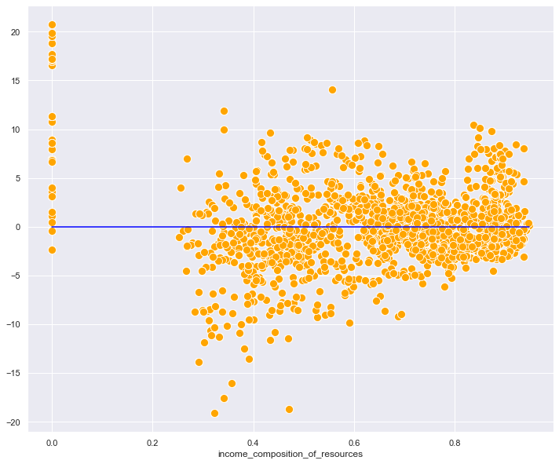

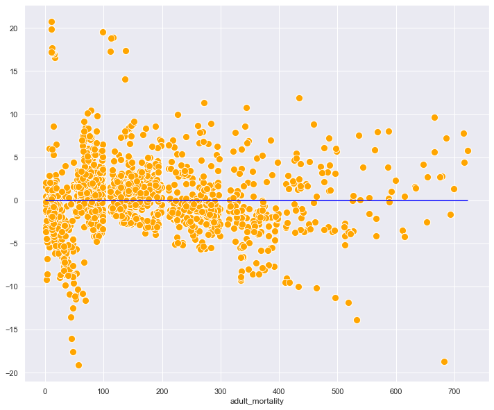

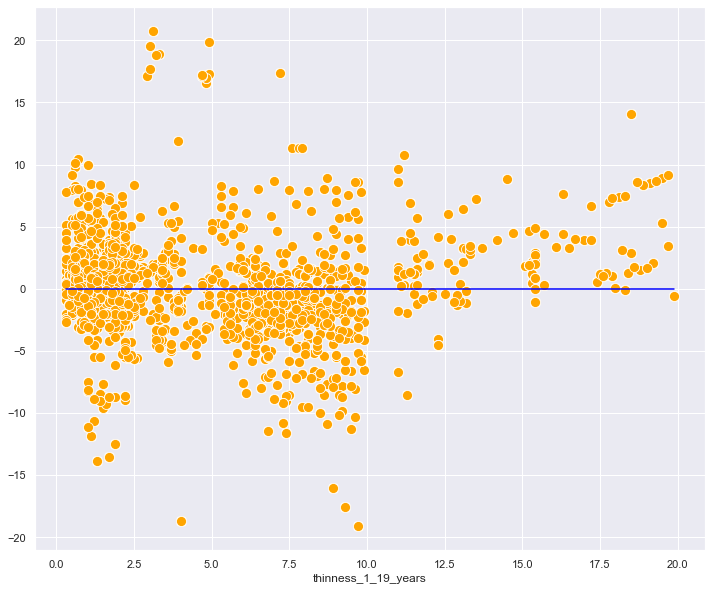

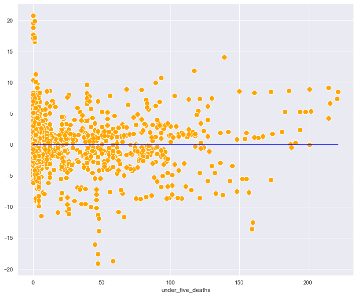

```python
# Quadratic and Cubic transformations needed

# Justification for transformation of income_composition_of_resources
sns.scatterplot(x = train.income_composition_of_resources, y = best_fwd_reg_model.resid, color = 'orange')
sns.lineplot(x = [train.income_composition_of_resources.min(),train.income_composition_of_resources.max()], y = [0,0], color = 'blue')
plt.show()

# Justification for transformation of adult_mortality
sns.scatterplot(x = train.adult_mortality, y = best_fwd_reg_model.resid, color = 'orange')
sns.lineplot(x = [train.adult_mortality.min(),train.adult_mortality.max()], y = [0,0], color = 'blue')
plt.show()

# Justification for transformation of thinness_1_19_years
sns.scatterplot(x = train.thinness_1_19_years, y = best_fwd_reg_model.resid, color = 'orange')
sns.lineplot(x = [train.thinness_1_19_years.min(),train.thinness_1_19_years.max()], y = [0,0], color = 'blue')
plt.show()

# Justification for transformation of under_five_deaths
sns.scatterplot(x = train.under_five_deaths, y = best_fwd_reg_model.resid, color = 'orange')
sns.lineplot(x = [train.under_five_deaths.min(),train.under_five_deaths.max()], y = [0,0], color = 'blue')
plt.show()
```

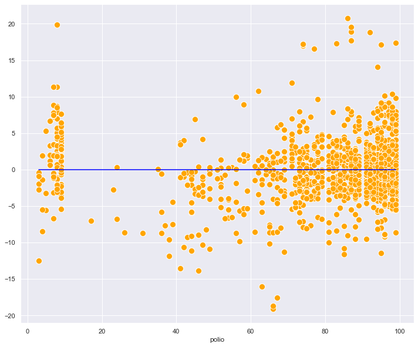

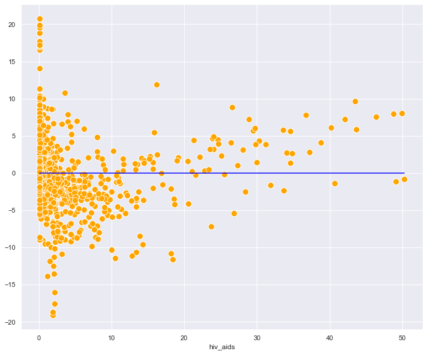

```python
# Quadratic, Cubic, and log transformations needed

# Justification for transformation of polio
sns.scatterplot(x = train.polio, y = best_fwd_reg_model.resid, color = 'orange')
sns.lineplot(x = [train.polio.min(),train.polio.max()], y = [0,0], color = 'blue')
plt.show()

# Justification for transformation of hiv_aids
sns.scatterplot(x = train.hiv_aids, y = best_fwd_reg_model.resid, color = 'orange')
sns.lineplot(x = [train.hiv_aids.min(),train.hiv_aids.max()], y = [0,0], color = 'blue')
plt.show()
```

```python
# Final model with transformations
ols_object = sm.ols(formula = 'life_expectancy~adult_mortality+I(adult_mortality**2)+I(adult_mortality**3)+income_composition_of_resources+I(income_composition_of_resources**2)+I(income_composition_of_resources**3)+measles+under_five_deaths+I(under_five_deaths**2)+I(under_five_deaths**3)+polio+I(polio**2)+I(polio**3)+np.log(polio)+diphtheria+hiv_aids+I(hiv_aids**2)+I(hiv_aids**3)+np.log(hiv_aids)+gdp_per_capita+thinness_1_19_years+I(thinness_1_19_years**2)', data=train)
model = ols_object.fit()

pred_life_exp3 = model.predict(test)
print('RMSE:', np.sqrt(((pred_life_exp3 - test.life_expectancy)**2).mean()))
print(model.summary())
```

```
RMSE: 2.9309546642831292
                            OLS Regression Results
==============================================================================
Dep. Variable:        life_expectancy   R-squared:                       0.922
Model:                            OLS   Adj. R-squared:                  0.922
Method:                 Least Squares   F-statistic:                     8483.
Date:                Sun, 12 Mar 2023   Prob (F-statistic):               0.00
Time:                        15:17:34   Log-Likelihood:                -39337.
No. Observations:               15773   AIC:                         7.872e+04
Df Residuals:                   15750   BIC:                         7.890e+04
Df Model:                          22
Covariance Type:            nonrobust
===========================================================================================================
                                              coef    std err          t      P>|t|      [0.025      0.975]
-----------------------------------------------------------------------------------------------------------
Intercept                                  49.9764      0.806     61.988      0.000      48.396      51.557
adult_mortality                             0.0059      0.001      5.113      0.000       0.004       0.008
I(adult_mortality ** 2)                  -4.09e-05   5.13e-06     -7.968      0.000    -5.1e-05   -3.08e-05
I(adult_mortality ** 3)                   1.34e-08   5.76e-09      2.325      0.020     2.1e-09    2.47e-08
income_composition_of_resources           -34.9919      1.329    -26.324      0.000     -37.597     -32.386
I(income_composition_of_resources ** 2)    93.9811      3.151     29.822      0.000      87.804     100.158
I(income_composition_of_resources ** 3)   -43.8372      2.065    -21.230      0.000     -47.885     -39.790
measles                                  1.537e-05   3.99e-06      3.848      0.000    7.54e-06    2.32e-05
under_five_deaths                          -0.0100      0.004     -2.552      0.011      -0.018      -0.002
I(under_five_deaths ** 2)                  -0.0003   5.61e-05     -5.806      0.000      -0.000      -0.000
I(under_five_deaths ** 3)                1.678e-06   2.03e-07      8.272      0.000    1.28e-06    2.08e-06
polio                                      -1.6910      0.058    -29.280      0.000      -1.804      -1.578
I(polio ** 2)                               0.0229      0.001     31.943      0.000       0.021       0.024
I(polio ** 3)                              -0.0001   3.31e-06    -32.025      0.000      -0.000   -9.94e-05
np.log(polio)                              13.4166      0.581     23.090      0.000      12.278      14.556
diphtheria                                  0.0101      0.002      6.482      0.000       0.007       0.013
hiv_aids                                   -0.5831      0.040    -14.512      0.000      -0.662      -0.504
I(hiv_aids ** 2)                            0.0250      0.002     11.687      0.000       0.021       0.029
I(hiv_aids ** 3)                           -0.0004   3.11e-05    -11.642      0.000      -0.000      -0.000
np.log(hiv_aids)                           -0.8096      0.050    -16.097      0.000      -0.908      -0.711
gdp_per_capita                           1.079e-05   2.26e-06      4.777      0.000    6.36e-06    1.52e-05
thinness_1_19_years                        -0.5406      0.022    -24.537      0.000      -0.584      -0.497
I(thinness_1_19_years ** 2)                 0.0284      0.001     21.665      0.000       0.026       0.031
==============================================================================
Omnibus:                      765.348   Durbin-Watson:                   2.005
Prob(Omnibus):                  0.000   Jarque-Bera (JB):             2789.230
Skew:                           0.063   Prob(JB):                         0.00
Kurtosis:                       5.056   Cond. No.                     7.56e+09
==============================================================================

Notes:
[1] Standard Errors assume that the covariance matrix of the errors is correctly specified.
[2] The condition number is large, 7.56e+09. This might indicate that there are
strong multicollinearity or other numerical problems.
```

```python
reset_index_train = train.reset_index()
reset_index_train
```

|  | index | country | year | status | life_expectancy | adult_mortality | measles | under_five_deaths | polio | diphtheria | hiv_aids | gdp_per_capita | thinness_1_19_years | thinness_5_9_years | income_composition_of_resources | schooling | continent |
| --- | --- | --- | --- | --- | --- | --- | --- | --- | --- | --- | --- | --- | --- | --- | --- | --- | --- |
| 0 | 310 | Albania | 2003 | Developing | 72.8 | 18.0 | 8 | 1 | 97.0 | 97.0 | 0.1 | 189.681557 | 1.9 | 2.0 | 0.674 | 10.7 | Europe |
| 1 | 1591 | Bangladesh | 2007 | Developing | 68.6 | 151.0 | 2924 | 201 | 96.0 | 94.0 | 0.1 | 541.651484 | 19.5 | 2.1 | 0.513 | 8.6 | Asia |
| 2 | 2506 | Brazil | 2000 | Developing | 75.0 | 183.0 | 36 | 127 | 99.0 | 98.0 | 0.1 | 3739.119360 | 3.4 | 3.4 | 0.677 | 14.1 | Americas |
| 3 | 10346 | Lebanon | 2013 | Developing | 74.9 | 97.0 | 1761 | 1 | 75.0 | 81.0 | 0.1 | 846.285153 | 4.8 | 4.8 | 0.766 | 13.3 | Asia |
| 4 | 798 | Argentina | 2009 | Developing | 75.6 | 126.0 | 3 | 11 | 97.0 | 94.0 | 0.1 | 8161.369660 | 1.0 | 0.9 | 0.794 | 16.5 | Americas |
| ... | ... | ... | ... | ... | ... | ... | ... | ... | ... | ... | ... | ... | ... | ... | ... | ... | ... |
| 15768 | 9896 | Jordan | 2006 | Developing | 72.8 | 121.0 | 1 | 4 | 98.0 | 98.0 | 0.1 | 2537.349000 | 3.9 | 3.8 | 0.733 | 13.7 | Asia |
| 15769 | 7647 | Guinea | 2006 | Developing | 55.6 | 317.0 | 4 | 49 | 53.0 | 57.0 | 2.6 | 296.683820 | 9.1 | 9.1 | 0.356 | 7.1 | Africa |
| 15770 | 12826 | Mozambique | 2001 | Developing | 49.5 | 48.0 | 7085 | 132 | 72.0 | 73.0 | 13.4 | 256.441487 | 4.1 | 4.0 | 0.298 | 5.8 | Africa |
| 15771 | 11274 | Malawi | 2000 | Developing | 43.1 | 588.0 | 304 | 84 | 73.0 | 75.0 | 25.5 | 153.259487 | 8.0 | 7.9 | 0.391 | 10.7 | Africa |
| 15772 | 14316 | Oman | 2013 | Developing | 76.2 | 12.0 | 0 | 1 | 99.0 | 98.0 | 0.1 | 21268.756400 | 7.0 | 6.8 | 0.796 | 13.7 | Asia |

15773 rows × 17 columns

```python
out = model.outlier_test()
out
```

|  | student_resid | unadj_p | bonf(p) |
| --- | --- | --- | --- |
| 310 | -0.282488 | 0.777573 | 1.0 |
| 1591 | 0.041774 | 0.966680 | 1.0 |
| 2506 | 1.851319 | 0.064142 | 1.0 |
| 10346 | 0.076597 | 0.938945 | 1.0 |
| 798 | -0.758956 | 0.447890 | 1.0 |
| ... | ... | ... | ... |
| 9896 | -0.650857 | 0.515148 | 1.0 |
| 7647 | 1.017814 | 0.308782 | 1.0 |
| 12826 | -0.629914 | 0.528760 | 1.0 |
| 11274 | -0.262928 | 0.792610 | 1.0 |
| 14316 | 0.059483 | 0.952568 | 1.0 |

15773 rows × 3 columns

```python
#Computing the leverage statistic for each observation
influence = model.get_influence()
leverage = influence.hat_matrix_diag
#Average leverage of points
average_leverage = (model.df_model+1)/model.nobs
average_leverage
# Determine the cutoff for high leverage - general convention is 4x the average leverage
cutoff = 4*((model.df_model+1)/model.nobs)
#Number of high leverage points in the dataset
np.sum(leverage>cutoff)
```

```
485
```

```python
#Dropping influential points from data
train_filtered = reset_index_train.drop(np.intersect1d(np.where(np.abs(out.student_resid)>3)[0],(np.where(leverage>cutoff)[0])))
```

```python
# final model with influential points dropped
ols_object = sm.ols(formula = 'life_expectancy~adult_mortality+I(adult_mortality**2)+I(adult_mortality**3)+income_composition_of_resources+I(income_composition_of_resources**2)+I(income_composition_of_resources**3)+measles+under_five_deaths+I(under_five_deaths**2)+I(under_five_deaths**3)+polio+I(polio**2)+I(polio**3)+np.log(polio)+diphtheria+hiv_aids+I(hiv_aids**2)+I(hiv_aids**3)+np.log(hiv_aids)+gdp_per_capita+thinness_1_19_years+I(thinness_1_19_years**2)', data=train_filtered)
model = ols_object.fit()

pred_life_exp3 = model.predict(test)
print('RMSE:', np.sqrt(((pred_life_exp3 - test.life_expectancy)**2).mean()))
print(model.summary())
```

```
RMSE: 2.926029154672585
                            OLS Regression Results
==============================================================================
Dep. Variable:        life_expectancy   R-squared:                       0.923
Model:                            OLS   Adj. R-squared:                  0.923
Method:                 Least Squares   F-statistic:                     8561.
Date:                Sun, 12 Mar 2023   Prob (F-statistic):               0.00
Time:                        15:21:45   Log-Likelihood:                -39179.
No. Observations:               15761   AIC:                         7.840e+04
Df Residuals:                   15738   BIC:                         7.858e+04
Df Model:                          22
Covariance Type:            nonrobust
===========================================================================================================
                                              coef    std err          t      P>|t|      [0.025      0.975]
-----------------------------------------------------------------------------------------------------------
Intercept                                  50.1502      0.800     62.702      0.000      48.583      51.718
adult_mortality                             0.0071      0.001      6.186      0.000       0.005       0.009
I(adult_mortality ** 2)                 -5.165e-05   5.13e-06    -10.062      0.000   -6.17e-05   -4.16e-05
I(adult_mortality ** 3)                  3.359e-08   5.85e-09      5.744      0.000    2.21e-08    4.51e-08
income_composition_of_resources           -35.8893      1.320    -27.194      0.000     -38.476     -33.302
I(income_composition_of_resources ** 2)    96.8442      3.131     30.931      0.000      90.707     102.981
I(income_composition_of_resources ** 3)   -45.8625      2.052    -22.350      0.000     -49.885     -41.840
measles                                  1.395e-05   3.96e-06      3.520      0.000    6.18e-06    2.17e-05
under_five_deaths                          -0.0088      0.004     -2.277      0.023      -0.016      -0.001
I(under_five_deaths ** 2)                  -0.0003   5.56e-05     -5.876      0.000      -0.000      -0.000
I(under_five_deaths ** 3)                1.651e-06   2.01e-07      8.205      0.000    1.26e-06    2.05e-06
polio                                      -1.6795      0.057    -29.315      0.000      -1.792      -1.567
I(polio ** 2)                               0.0228      0.001     32.126      0.000       0.021       0.024
I(polio ** 3)                              -0.0001   3.28e-06    -32.345      0.000      -0.000   -9.97e-05
np.log(polio)                              13.2702      0.576     23.020      0.000      12.140      14.400
diphtheria                                  0.0103      0.002      6.666      0.000       0.007       0.013
hiv_aids                                   -0.5612      0.040    -14.072      0.000      -0.639      -0.483
I(hiv_aids ** 2)                            0.0208      0.002      9.702      0.000       0.017       0.025
I(hiv_aids ** 3)                           -0.0003   3.11e-05     -9.347      0.000      -0.000      -0.000
np.log(hiv_aids)                           -0.7894      0.050    -15.818      0.000      -0.887      -0.692
gdp_per_capita                            1.11e-05   2.24e-06      4.956      0.000    6.71e-06    1.55e-05
thinness_1_19_years                        -0.5468      0.022    -25.014      0.000      -0.590      -0.504
I(thinness_1_19_years ** 2)                 0.0289      0.001     22.207      0.000       0.026       0.031
==============================================================================
Omnibus:                      764.368   Durbin-Watson:                   2.007
Prob(Omnibus):                  0.000   Jarque-Bera (JB):             2638.069
Skew:                           0.119   Prob(JB):                         0.00
Kurtosis:                       4.990   Cond. No.                     7.43e+09
==============================================================================

Notes:
[1] Standard Errors assume that the covariance matrix of the errors is correctly specified.
[2] The condition number is large, 7.43e+09. This might indicate that there are
strong multicollinearity or other numerical problems.
```

After dropping influential points the final model RMSE decreased from 2.93 to 2.926 years and R-squared increased from .922 to .923.

```python
# final model with continent as a categorical variable
ols_object = sm.ols(formula = 'life_expectancy~adult_mortality+I(adult_mortality**2)+I(adult_mortality**3)+income_composition_of_resources+I(income_composition_of_resources**2)+I(income_composition_of_resources**3)+measles+under_five_deaths+I(under_five_deaths**2)+I(under_five_deaths**3)+polio+I(polio**2)+I(polio**3)+np.log(polio)+diphtheria+hiv_aids+I(hiv_aids**2)+I(hiv_aids**3)+np.log(hiv_aids)+gdp_per_capita+thinness_1_19_years+I(thinness_1_19_years**2)+continent', data=train_filtered)
model = ols_object.fit()

pred_life_exp3 = model.predict(test)
print('RMSE:', np.sqrt(((pred_life_exp3 - test.life_expectancy)**2).mean()))
print(model.summary())
```

```
RMSE: 2.8389111826271027
                            OLS Regression Results
==============================================================================
Dep. Variable:        life_expectancy   R-squared:                       0.927
Model:                            OLS   Adj. R-squared:                  0.927
Method:                 Least Squares   F-statistic:                     7720.
Date:                Sun, 12 Mar 2023   Prob (F-statistic):               0.00
Time:                        15:21:46   Log-Likelihood:                -38714.
No. Observations:               15761   AIC:                         7.748e+04
Df Residuals:                   15734   BIC:                         7.769e+04
Df Model:                          26
Covariance Type:            nonrobust
===========================================================================================================
                                              coef    std err          t      P>|t|      [0.025      0.975]
-----------------------------------------------------------------------------------------------------------
Intercept                                  48.4443      0.780     62.145      0.000      46.916      49.972
continent[T.Americas]                       3.0393      0.107     28.483      0.000       2.830       3.248
continent[T.Asia]                           0.8014      0.098      8.182      0.000       0.609       0.993
continent[T.Europe]                         1.7858      0.117     15.258      0.000       1.556       2.015
continent[T.Oceania]                        1.6200      0.210      7.719      0.000       1.209       2.031
adult_mortality                             0.0049      0.001      4.362      0.000       0.003       0.007
I(adult_mortality ** 2)                 -3.634e-05   5.02e-06     -7.241      0.000   -4.62e-05   -2.65e-05
I(adult_mortality ** 3)                  1.448e-08   5.73e-09      2.528      0.011    3.25e-09    2.57e-08
income_composition_of_resources           -27.6831      1.324    -20.914      0.000     -30.278     -25.089
I(income_composition_of_resources ** 2)    69.7749      3.229     21.606      0.000      63.445      76.105
I(income_composition_of_resources ** 3)   -25.8826      2.159    -11.988      0.000     -30.114     -21.651
measles                                   1.64e-05   3.86e-06      4.255      0.000    8.85e-06     2.4e-05
under_five_deaths                          -0.0149      0.004     -3.947      0.000      -0.022      -0.008
I(under_five_deaths ** 2)                  -0.0002   5.42e-05     -4.155      0.000      -0.000      -0.000
I(under_five_deaths ** 3)                1.406e-06   1.96e-07      7.185      0.000    1.02e-06    1.79e-06
polio                                      -1.5793      0.056    -28.247      0.000      -1.689      -1.470
I(polio ** 2)                               0.0215      0.001     30.865      0.000       0.020       0.023
I(polio ** 3)                           -9.929e-05   3.22e-06    -30.873      0.000      -0.000    -9.3e-05
np.log(polio)                              12.4113      0.561     22.112      0.000      11.311      13.512
diphtheria                                  0.0110      0.002      7.305      0.000       0.008       0.014
hiv_aids                                   -0.4139      0.039    -10.593      0.000      -0.491      -0.337
I(hiv_aids ** 2)                            0.0158      0.002      7.559      0.000       0.012       0.020
I(hiv_aids ** 3)                           -0.0002   3.03e-05     -7.783      0.000      -0.000      -0.000
np.log(hiv_aids)                           -0.9719      0.050    -19.399      0.000      -1.070      -0.874
gdp_per_capita                           1.399e-05   2.19e-06      6.393      0.000     9.7e-06    1.83e-05
thinness_1_19_years                        -0.1259      0.026     -4.857      0.000      -0.177      -0.075
I(thinness_1_19_years ** 2)                 0.0092      0.001      6.314      0.000       0.006       0.012
==============================================================================
Omnibus:                     1011.389   Durbin-Watson:                   2.004
Prob(Omnibus):                  0.000   Jarque-Bera (JB):             3872.854
Skew:                           0.221   Prob(JB):                         0.00
Kurtosis:                       5.388   Cond. No.                     7.91e+09
==============================================================================

Notes:
[1] Standard Errors assume that the covariance matrix of the errors is correctly specified.
[2] The condition number is large, 7.91e+09. This might indicate that there are
strong multicollinearity or other numerical problems.
```

- Adding continent increased R-squared and decreased RMSE which means it improved our model

```python
# final model with continent as a categorical variable
# sacrificing some RMSE and R-squared by removing some interactions and transformations to make the model more interpretable for inference
ols_object = sm.ols(formula = 'life_expectancy~continent+income_composition_of_resources+I(income_composition_of_resources**2)+measles+under_five_deaths+polio+diphtheria+diphtheria*continent+hiv_aids+np.log(gdp_per_capita)', data=train_filtered)
model = ols_object.fit()

pred_life_exp3 = model.predict(test)
print('RMSE:', np.sqrt(((pred_life_exp3 - test.life_expectancy)**2).mean()))
print(model.summary())
```

```
RMSE: 3.264514824464634
                            OLS Regression Results
==============================================================================
Dep. Variable:        life_expectancy   R-squared:                       0.901
Model:                            OLS   Adj. R-squared:                  0.901
Method:                 Least Squares   F-statistic:                     8942.
Date:                Sun, 12 Mar 2023   Prob (F-statistic):               0.00
Time:                        15:21:46   Log-Likelihood:                -41159.
No. Observations:               15761   AIC:                         8.235e+04
Df Residuals:                   15744   BIC:                         8.248e+04
Df Model:                          16
Covariance Type:            nonrobust
===========================================================================================================
                                              coef    std err          t      P>|t|      [0.025      0.975]
-----------------------------------------------------------------------------------------------------------
Intercept                                  54.3344      0.256    212.612      0.000      53.833      54.835
continent[T.Americas]                       8.8612      0.293     30.209      0.000       8.286       9.436
continent[T.Asia]                           8.4463      0.303     27.834      0.000       7.851       9.041
continent[T.Europe]                         9.9788      0.390     25.603      0.000       9.215      10.743
continent[T.Oceania]                        6.7488      0.555     12.153      0.000       5.660       7.837
income_composition_of_resources           -15.5976      0.643    -24.252      0.000     -16.858     -14.337
I(income_composition_of_resources ** 2)    38.2380      0.652     58.640      0.000      36.960      39.516
measles                                   1.56e-05   4.41e-06      3.535      0.000    6.95e-06    2.42e-05
under_five_deaths                          -0.0205      0.001    -23.117      0.000      -0.022      -0.019
polio                                       0.0179      0.002     10.973      0.000       0.015       0.021
diphtheria                                  0.0562      0.002     28.339      0.000       0.052       0.060
diphtheria:continent[T.Americas]           -0.0414      0.003    -12.370      0.000      -0.048      -0.035
diphtheria:continent[T.Asia]               -0.0597      0.004    -16.815      0.000      -0.067      -0.053
diphtheria:continent[T.Europe]             -0.0703      0.004    -16.945      0.000      -0.078      -0.062
diphtheria:continent[T.Oceania]            -0.0429      0.006     -6.635      0.000      -0.056      -0.030
hiv_aids                                   -0.4475      0.005    -90.793      0.000      -0.457      -0.438
np.log(gdp_per_capita)                      0.0736      0.024      3.048      0.002       0.026       0.121
==============================================================================
Omnibus:                      860.048   Durbin-Watson:                   1.976
Prob(Omnibus):                  0.000   Jarque-Bera (JB):             3109.265
Skew:                           0.161   Prob(JB):                         0.00
Kurtosis:                       5.152   Cond. No.                     2.35e+05
==============================================================================

Notes:
[1] Standard Errors assume that the covariance matrix of the errors is correctly specified.
[2] The condition number is large, 2.35e+05. This might indicate that there are
strong multicollinearity or other numerical problems.
```